# Novarties_Hackathon

## Introduction to Machine learning

Machine learning (ML) is a category of an algorithm that allows software applications to become more accurate in predicting outcomes without being explicitly programmed. The basic premise of machine learning is to build algorithms that can receive input data and use statistical analysis to predict an output

[figure not shown]

**Need For Machine Learning:**

**Increase in Data Generation:** Due to excessive production of data, we need a method that can be used to structure, analyze and draw useful insights from data. This is where Machine Learning comes in. It uses data to solve problems and find solutions to the most complex tasks faced by organizations.

**Improve Decision Making:** By making use of various algorithms, Machine Learning can be used to make better business decisions. For example, Machine Learning is used to forecast sales, predict downfalls in the stock market, identify risks and anomalies, etc.

**Uncover patterns & trends in data:** Finding hidden patterns and extracting key insights from data is the most essential part of Machine Learning. By building predictive models and using statistical techniques, Machine Learning allows you to dig beneath the surface and explore the data at a minute scale. Understanding data and extracting patterns manually will take days, whereas Machine Learning algorithms can perform such computations in less than a second.

**Solve complex problems:** From detecting the genes linked to the deadly ALS disease to building self-driving cars, Machine Learning can be used to solve the most complex problems.

[figure not shown]

EX:

**Netflix’s Recommendation Engine:** The core of Netflix is its infamous recommendation engine. Over 75% of what you watch is recommended by Netflix and these recommendations are made by implementing Machine Learning.

**Facebook’s Auto-tagging feature:** The logic behind Facebook’s DeepMind face verification system is Machine Learning and Neural Networks. DeepMind studies the facial features in an image to tag your friends and family.

**Amazon’s Alexa:** The infamous Alexa, which is based on Natural Language Processing and Machine Learning is an advanced level Virtual Assistant that does more than just play songs on your playlist. It can book you an Uber, connect with the other IoT devices at home, track your health, etc.

**Google’s Spam Filter:** Gmail makes use of Machine Learning to filter out spam messages. It uses Machine Learning algorithms and Natural Language Processing to analyze emails in real-time and classify them as either spam or non-spam.

## Machine Learning Components

**Algorithm:** A Machine Learning algorithm is a set of rules and statistical techniques used to learn patterns from data and draw significant information from it. It is the logic behind a Machine Learning model. An example of a Machine Learning algorithm is the Linear Regression algorithm.

**Model:** A model is the main component of Machine Learning. A model is trained by using a Machine Learning Algorithm. An algorithm maps all the decisions that a model is supposed to take based on the given input, in order to get the correct output.

**Predictor Variable:** It is a feature(s) of the data that can be used to predict the output.

**Response Variable:** It is the feature or the output variable that needs to be predicted by using the predictor variable(s).

**Training Data:** The Machine Learning model is built using the training data. The training data helps the model to identify key trends and patterns essential to predict the output.

**Testing Data:** After the model is trained, it must be tested to evaluate how accurately it can predict an outcome. This is done by the testing data set.

[figure not shown]

## Machine Learning Process

**Define the objective of the Problem Statement:** we must understand what exactly needs to be predicted.

**Data Gathering:** At this stage, you must be asking questions such as,

What kind of data is needed to solve this problem? Is the data available? How can I get the data?

Once you know the types of data that is required, you must understand how you can derive this data. Data collection can be done manually or by web scraping.

**Data Preparation:** The data you collected is almost never in the right format. You will encounter a lot of inconsistencies in the data set such as missing values, redundant variables, duplicate values, etc. Removing such inconsistencies is very essential because they might lead to wrongful computations and predictions.

**Exploratory Data Analysis:** EDA is the brainstorming stage of Machine Learning. Data Exploration involves understanding the patterns and trends in the data and all the useful insights are drawn.

**Building a Machine Learning Model:** All the insights and patterns derived during Data Exploration are used to build the Machine Learning Model. This stage always begins by splitting the data set into two parts, training data, and testing data. The training data will be used to build and analyze the model. The logic of the model is based on the Machine Learning Algorithm that is being implemented.Choosing the right algorithm depends on the type of problem you’re trying to solve, the data set and the level of complexity of the problem.

**Model Evaluation & Optimization:** After building a model by using the training data set, it is finally time to put the model to a test. The testing data set is used to check the efficiency of the model and how accurately it can predict the outcome. Once the accuracy is calculated, any further improvements in the model can be implemented at this stage. Methods like parameter tuning and cross-validation can be used to improve the performance of the model.

**Predictions:** Once the model is evaluated and improved, it is finally used to make predictions. The final output can be a Categorical variable (eg. True or False) or it can be a Continuous Quantity (eg. the predicted value of a stock).

[figure not shown]

## Machine Learning Types

A machine can learn to solve a problem by following any one of the following three approaches. These are the ways in which a machine can learn:

1)Supervised Learning 2)Unsupervised Learning 3)Reinforcement Learning

[figure not shown]

**Supervised Learning:** Supervised learning is a technique in which we teach or train the machine using data which is well labeled.Labelled data is past input and output pairs provided during the learning process to teach the model how it should behave

Ex: classifying whether an email is spam or not,predicting stock market price.

[figure not shown]

**Types of Supervised Learning:**

**1)Classification:** Classification is used to group the similar data points into different sections in order to classify them.Output variable is a category. A problem like, “Will he make this purchase” will have an answer that falls into two specific categories: yes or no. This is also called a, binary classification problem.

**Ex Models:** Logistic Regression,Naive Bayes,Decision Tree,KNN,Random Forest,Stacking,Bagging,Boosting(AdaBoost,GraidentBoost,XGBoost),SVM,Nueral Network,

[figure not shown]

**2)Regression:** Output variable is a real or continuous value.If you want to predict continuous values, such as trying to predict the cost of a house or the weather outside in degrees, you would use regression.

**Ex Models:** Linear Regression,Decision Tree,KNN,Random Forest,Stacking,Bagging,Boosting(AdaBoost,GraidentBoost,XGBoost),SVR,Nueral Network,

[figure not shown]

**Unsupervised Learning:** Unsupervised learning involves training by using unlabeled data and allowing the model to act on that information without guidance.Meaning, there is no “right” answer given to the machine to learn, but the machine must hopefully find patterns from the data to come up with an answer.

[figure not shown]

Ex: grouping customers by purchasing behavior.

**1)Clustering:** A clustering problem involves assigning the input into two or more clusters based on feature similarity. For example, clustering viewers into similar groups based on their interests, age, geography, etc can be done by using Unsupervised Learning algorithms like K-Means Clustering.

**Ex Models:** K-Mean,K-Medoids,Hierarchical clustering

[figure not shown]

**2)Association:** An association rule learning problem is where you want to discover rules that describe large portions of your data, such as people that buy X also tend to buy Y.

**Ex Models:** Apriori algorithm

[figure not shown]

**Reinforcement Learning:** Reinforcement Learning is a part of Machine learning where an agent is put in an environment and he learns to behave in this environment by performing certain actions and observing the rewards which it gets from those actions.

Ex: Training a machine to learn how to play (Chess, Go),Self-driving cars.

[figure not shown]

## Problem Statement

**Predict if the server will be hacked**

All the countries across the globe have adapted to means of digital payments. And with the increased volume of digital payments, hacking has become a pretty common event wherein the hacker can try to hack your details just with your phone number linked to your bank account. However, there is data with some anonymized variables based on which one can predict that the hack is going to happen.

**Data**

| **Column** | **Description** |
| --- | --- |
| INCIDENT_ID | Unique identifier for an incident log |
| DATE | Date wof incident occurence |
| X_1-X_15 | Anonymized logging parameters |
| MULTIPLE_OFFENSE | [Target] Indicates if the incident was a hack [1: Yes; 0: No] |

**Data Files**

```
Train.csv : Training data [23856 x 18] to be used for training of model

Test.csv : Test data [15903 x 17] on which predictions need to be made

sample_submission.csv : submission format that needs to be followed when uploading predictions on platform
```

**Evaluation Criteria:**

[figure not shown]

**score = recall_score(actual_values,predicted_values)**

**Submission Format:**

You need to upload your predictions in a .csv format under 'Upload File' section.

```
Please ensure the format of the file matches the sample_submission.csv provided to avoid any exceptions.

Please ensure the 'INCIDENT_ID' column values match the test data's 'INCIDENT_ID' values to avoid any exceptions.
```

You need to upload your notebook file containing detailed documentation of your approach on EDA & algorithm choice under 'Upload Source Code'.

```python
## Import necessary Libraries.

import pandas as pd ## Pandas Library (will use to load data,create data frame...etc).
import numpy as np ## Numpy Library ( will use to convert data frame to array or creating array etc...).
import os ## For connecting to machine to get path for reading/writing files.
import matplotlib.pyplot as plt # For Visualization.
import seaborn as sns # For Visualization.
# Magic command.
%matplotlib inline
from sklearn.model_selection import train_test_split ## For splitting data into train and validation.
from sklearn.preprocessing import LabelEncoder ## For label encoding(converting categorical values to label).
from xgboost import XGBClassifier ## XG boost model.
from sklearn.model_selection import GridSearchCV ##For Grid search(cross validation).
from sklearn.metrics import accuracy_score ## For getting accuracy value.
from sklearn.metrics import confusion_matrix,classification_report,recall_score ## For classifier metrics(accuracy,TPR,TNR).
```

```python
## Get current working directory.
os.getcwd()
```

```
'D:\\Python\\Pratice\\Novartis_Data_Science_Hackathonn'
```

```python
## Set working directory.
os.chdir("D:/DataScience/Pratice/Novarties_Hackathon/Dataset/")
os.getcwd()
```

```
'D:\\DataScience\\Pratice\\Novarties_Hackathon\\Dataset'
```

```python
## Load train and test data.
train = pd.read_csv('Train.csv',header='infer',sep=',')
test = pd.read_csv('Test.csv',header='infer',sep=',')
```

```python
## Check dimesnions of train and test data.
print(train.shape)
print(test.shape)
```

```
(23856, 18)
(15903, 17)
```

```python
## Check first row of train data.
train.head(1)
```

|  | INCIDENT_ID | DATE | X_1 | X_2 | X_3 | X_4 | X_5 | X_6 | X_7 | X_8 | X_9 | X_10 | X_11 | X_12 | X_13 | X_14 | X_15 | MULTIPLE_OFFENSE |
| --- | --- | --- | --- | --- | --- | --- | --- | --- | --- | --- | --- | --- | --- | --- | --- | --- | --- | --- |
| 0 | CR_102659 | 04-JUL-04 | 0 | 36 | 34 | 2 | 1 | 5 | 6 | 1 | 6 | 1 | 174 | 1.0 | 92 | 29 | 36 | 0 |

```python
## Check last row of train data.
train.tail(1)
```

|  | INCIDENT_ID | DATE | X_1 | X_2 | X_3 | X_4 | X_5 | X_6 | X_7 | X_8 | X_9 | X_10 | X_11 | X_12 | X_13 | X_14 | X_15 | MULTIPLE_OFFENSE |
| --- | --- | --- | --- | --- | --- | --- | --- | --- | --- | --- | --- | --- | --- | --- | --- | --- | --- | --- |
| 23855 | CR_22575 | 08-NOV-94 | 7 | 36 | 34 | 2 | 1 | 9 | 8 | 0 | 5 | 1 | 249 | 1.0 | 92 | 29 | 34 | 1 |

```python
## Check first row of test data.
test.head(1)
```

|  | INCIDENT_ID | DATE | X_1 | X_2 | X_3 | X_4 | X_5 | X_6 | X_7 | X_8 | X_9 | X_10 | X_11 | X_12 | X_13 | X_14 | X_15 |
| --- | --- | --- | --- | --- | --- | --- | --- | --- | --- | --- | --- | --- | --- | --- | --- | --- | --- |
| 0 | CR_195453 | 01-FEB-18 | 0 | 30 | 35 | 7 | 3 | 6 | 4 | 0 | 5 | 1 | 174 | NaN | 72 | 119 | 23 |

```python
## Check last row of test data.
test.tail(1)
```

|  | INCIDENT_ID | DATE | X_1 | X_2 | X_3 | X_4 | X_5 | X_6 | X_7 | X_8 | X_9 | X_10 | X_11 | X_12 | X_13 | X_14 | X_15 |
| --- | --- | --- | --- | --- | --- | --- | --- | --- | --- | --- | --- | --- | --- | --- | --- | --- | --- |
| 15902 | CR_33545 | 24-APR-96 | 0 | 4 | 4 | 6 | 5 | 4 | 2 | 5 | 6 | 1 | 249 | 1.0 | 72 | 29 | 34 |

```python
## Check summary statistics of train data.
train.describe(include='all')
```

|  | INCIDENT_ID | DATE | X_1 | X_2 | X_3 | X_4 | X_5 | X_6 | X_7 | X_8 | X_9 | X_10 | X_11 | X_12 | X_13 | X_14 | X_15 | MULTIPLE_OFFENSE |
| --- | --- | --- | --- | --- | --- | --- | --- | --- | --- | --- | --- | --- | --- | --- | --- | --- | --- | --- |
| count | 23856 | 23856 | 23856.000000 | 23856.000000 | 23856.000000 | 23856.000000 | 23856.000000 | 23856.000000 | 23856.000000 | 23856.000000 | 23856.000000 | 23856.000000 | 23856.000000 | 23674.000000 | 23856.000000 | 23856.000000 | 23856.000000 | 23856.000000 |
| unique | 23856 | 9121 | NaN | NaN | NaN | NaN | NaN | NaN | NaN | NaN | NaN | NaN | NaN | NaN | NaN | NaN | NaN | NaN |
| top | CR_105207 | 12-SEP-01 | NaN | NaN | NaN | NaN | NaN | NaN | NaN | NaN | NaN | NaN | NaN | NaN | NaN | NaN | NaN | NaN |
| freq | 1 | 22 | NaN | NaN | NaN | NaN | NaN | NaN | NaN | NaN | NaN | NaN | NaN | NaN | NaN | NaN | NaN | NaN |
| mean | NaN | NaN | 0.483778 | 24.791206 | 24.637450 | 4.276744 | 2.455609 | 6.154175 | 4.876509 | 0.972460 | 4.924128 | 1.244802 | 206.954519 | 0.974064 | 85.237383 | 72.674296 | 33.464747 | 0.955231 |
| std | NaN | NaN | 1.439738 | 15.240231 | 15.135093 | 2.944672 | 1.963095 | 4.471756 | 3.881931 | 1.453144 | 1.362625 | 1.119301 | 93.033348 | 1.167725 | 27.597226 | 43.297320 | 8.386834 | 0.206800 |
| min | NaN | NaN | 0.000000 | 0.000000 | 0.000000 | 0.000000 | 0.000000 | 1.000000 | 0.000000 | 0.000000 | 0.000000 | 1.000000 | 0.000000 | 0.000000 | 0.000000 | 0.000000 | 0.000000 | 0.000000 |
| 25% | NaN | NaN | 0.000000 | 7.000000 | 8.000000 | 2.000000 | 1.000000 | 3.000000 | 2.000000 | 0.000000 | 5.000000 | 1.000000 | 174.000000 | 1.000000 | 72.000000 | 29.000000 | 34.000000 | 1.000000 |
| 50% | NaN | NaN | 0.000000 | 24.000000 | 24.000000 | 4.000000 | 3.000000 | 5.000000 | 4.000000 | 1.000000 | 5.000000 | 1.000000 | 249.000000 | 1.000000 | 98.000000 | 62.000000 | 34.000000 | 1.000000 |
| 75% | NaN | NaN | 0.000000 | 36.000000 | 35.000000 | 6.000000 | 5.000000 | 8.000000 | 7.000000 | 1.000000 | 6.000000 | 1.000000 | 249.000000 | 1.000000 | 103.000000 | 107.000000 | 34.000000 | 1.000000 |
| max | NaN | NaN | 7.000000 | 52.000000 | 52.000000 | 10.000000 | 5.000000 | 19.000000 | 18.000000 | 99.000000 | 6.000000 | 90.000000 | 332.000000 | 90.000000 | 116.000000 | 142.000000 | 50.000000 | 1.000000 |

```python
## Check summary statistics of test data.
test.describe(include='all')
```

|  | INCIDENT_ID | DATE | X_1 | X_2 | X_3 | X_4 | X_5 | X_6 | X_7 | X_8 | X_9 | X_10 | X_11 | X_12 | X_13 | X_14 | X_15 |
| --- | --- | --- | --- | --- | --- | --- | --- | --- | --- | --- | --- | --- | --- | --- | --- | --- | --- |
| count | 15903 | 15903 | 15903.000000 | 15903.000000 | 15903.000000 | 15903.000000 | 15903.000000 | 15903.000000 | 15903.000000 | 15903.000000 | 15903.000000 | 15903.000000 | 15903.000000 | 15776.000000 | 15903.000000 | 15903.000000 | 15903.000000 |
| unique | 15903 | 7939 | NaN | NaN | NaN | NaN | NaN | NaN | NaN | NaN | NaN | NaN | NaN | NaN | NaN | NaN | NaN |
| top | CR_146650 | 13-SEP-01 | NaN | NaN | NaN | NaN | NaN | NaN | NaN | NaN | NaN | NaN | NaN | NaN | NaN | NaN | NaN |
| freq | 1 | 16 | NaN | NaN | NaN | NaN | NaN | NaN | NaN | NaN | NaN | NaN | NaN | NaN | NaN | NaN | NaN |
| mean | NaN | NaN | 0.468088 | 24.722631 | 24.575049 | 4.284223 | 2.448469 | 6.084890 | 4.862605 | 0.986732 | 4.908759 | 1.241212 | 206.954097 | 0.972236 | 85.191096 | 72.218575 | 33.422625 |
| std | NaN | NaN | 1.412112 | 15.228841 | 15.127451 | 2.974584 | 1.963372 | 4.451117 | 3.854550 | 1.471274 | 1.374677 | 0.841804 | 93.107783 | 0.876669 | 27.493192 | 43.438227 | 8.314284 |
| min | NaN | NaN | 0.000000 | 0.000000 | 0.000000 | 0.000000 | 0.000000 | 1.000000 | 0.000000 | 0.000000 | 0.000000 | 1.000000 | 0.000000 | 0.000000 | 0.000000 | 0.000000 | 0.000000 |
| 25% | NaN | NaN | 0.000000 | 7.000000 | 8.000000 | 2.000000 | 1.000000 | 3.000000 | 2.000000 | 0.000000 | 5.000000 | 1.000000 | 174.000000 | 1.000000 | 72.000000 | 29.000000 | 34.000000 |
| 50% | NaN | NaN | 0.000000 | 24.000000 | 24.000000 | 4.000000 | 3.000000 | 5.000000 | 4.000000 | 1.000000 | 5.000000 | 1.000000 | 249.000000 | 1.000000 | 98.000000 | 62.000000 | 34.000000 |
| 75% | NaN | NaN | 0.000000 | 36.000000 | 35.000000 | 6.000000 | 5.000000 | 8.000000 | 7.000000 | 1.000000 | 6.000000 | 1.000000 | 249.000000 | 1.000000 | 103.000000 | 107.000000 | 34.000000 |
| max | NaN | NaN | 7.000000 | 52.000000 | 52.000000 | 10.000000 | 5.000000 | 19.000000 | 18.000000 | 50.000000 | 6.000000 | 40.000000 | 332.000000 | 40.000000 | 117.000000 | 142.000000 | 50.000000 |

```python
## Check column names of train data.
train.columns
```

```
Index(['INCIDENT_ID', 'DATE', 'X_1', 'X_2', 'X_3', 'X_4', 'X_5', 'X_6', 'X_7',
       'X_8', 'X_9', 'X_10', 'X_11', 'X_12', 'X_13', 'X_14', 'X_15',
       'MULTIPLE_OFFENSE'],
      dtype='object')
```

```python
## Check column names of test data
test.columns
```

```
Index(['INCIDENT_ID', 'DATE', 'X_1', 'X_2', 'X_3', 'X_4', 'X_5', 'X_6', 'X_7',
       'X_8', 'X_9', 'X_10', 'X_11', 'X_12', 'X_13', 'X_14', 'X_15'],
      dtype='object')
```

```python
## Check column data types of train data.
train.dtypes
```

```
INCIDENT_ID          object
DATE                 object
X_1                   int64
X_2                   int64
X_3                   int64
X_4                   int64
X_5                   int64
X_6                   int64
X_7                   int64
X_8                   int64
X_9                   int64
X_10                  int64
X_11                  int64
X_12                float64
X_13                  int64
X_14                  int64
X_15                  int64
MULTIPLE_OFFENSE      int64
dtype: object
```

```python
## Check column data types of test data.
test.dtypes
```

```
INCIDENT_ID     object
DATE            object
X_1              int64
X_2              int64
X_3              int64
X_4              int64
X_5              int64
X_6              int64
X_7              int64
X_8              int64
X_9              int64
X_10             int64
X_11             int64
X_12           float64
X_13             int64
X_14             int64
X_15             int64
dtype: object
```

```python
## Check index range for train data.
train.index
```

```
RangeIndex(start=0, stop=23856, step=1)
```

```python
## Check index range for test data.
test.index
```

```
RangeIndex(start=0, stop=15903, step=1)
```

```python
## Check null values for train data.
train.isna().sum()
```

```
INCIDENT_ID           0
DATE                  0
X_1                   0
X_2                   0
X_3                   0
X_4                   0
X_5                   0
X_6                   0
X_7                   0
X_8                   0
X_9                   0
X_10                  0
X_11                  0
X_12                182
X_13                  0
X_14                  0
X_15                  0
MULTIPLE_OFFENSE      0
dtype: int64
```

```python
## Check null values for test data.
test.isna().sum()
```

```
INCIDENT_ID      0
DATE             0
X_1              0
X_2              0
X_3              0
X_4              0
X_5              0
X_6              0
X_7              0
X_8              0
X_9              0
X_10             0
X_11             0
X_12           127
X_13             0
X_14             0
X_15             0
dtype: int64
```

```python
## this method will return number of levels,null values,unique values,data types.

def observations(df):
    return(pd.DataFrame({'dtypes' : df.dtypes,
                         'levels' : [df[x].unique() for x in df.columns],
                         'null_values' : df.isnull().sum(),
                         'Unique Values': df.nunique()
                        }))
```

```python
## Get train data statistics.
observations(train)
```

|  | dtypes | levels | null_values | Unique Values |
| --- | --- | --- | --- | --- |
| INCIDENT_ID | object | [CR_102659, CR_189752, CR_184637, CR_139071, C... | 0 | 23856 |
| DATE | object | [04-JUL-04, 18-JUL-17, 15-MAR-17, 13-FEB-09, 1... | 0 | 9121 |
| X_1 | int64 | [0, 1, 5, 7, 3, 4, 2, 6] | 0 | 8 |
| X_2 | int64 | [36, 37, 3, 33, 45, 30, 8, 49, 4, 7, 25, 21, 4... | 0 | 52 |
| X_3 | int64 | [34, 37, 2, 32, 45, 35, 7, 49, 4, 8, 25, 23, 4... | 0 | 52 |
| X_4 | int64 | [2, 0, 3, 10, 7, 6, 9, 4, 1, 5] | 0 | 10 |
| X_5 | int64 | [1, 0, 5, 3, 2] | 0 | 5 |
| X_6 | int64 | [5, 11, 1, 7, 8, 9, 15, 2, 4, 13, 3, 16, 6, 18... | 0 | 19 |
| X_7 | int64 | [6, 17, 0, 1, 3, 8, 10, 7, 2, 18, 5, 12, 4, 13... | 0 | 19 |
| X_8 | int64 | [1, 2, 0, 3, 4, 5, 7, 6, 12, 10, 8, 20, 11, 15... | 0 | 24 |
| X_9 | int64 | [6, 3, 5, 1, 2, 0, 4] | 0 | 7 |
| X_10 | int64 | [1, 2, 3, 4, 6, 12, 5, 11, 10, 90, 20, 8, 16, ... | 0 | 24 |
| X_11 | int64 | [174, 236, 249, 303, 316, 145, 0, 127, 299, 15... | 0 | 133 |
| X_12 | float64 | [1.0, 0.0, 3.0, 2.0, 6.0, 12.0, 4.0, nan, 5.0,... | 182 | 23 |
| X_13 | int64 | [92, 103, 110, 72, 112, 42, 18, 2, 98, 67, 116... | 0 | 60 |
| X_14 | int64 | [29, 142, 93, 62, 14, 130, 133, 115, 53, 80, 1... | 0 | 62 |
| X_15 | int64 | [36, 34, 43, 48, 46, 0, 23, 9, 50, 39, 24, 14,... | 0 | 28 |
| MULTIPLE_OFFENSE | int64 | [0, 1] | 0 | 2 |

```python
## Get test data statistics.
observations(test)
```

|  | dtypes | levels | null_values | Unique Values |
| --- | --- | --- | --- | --- |
| INCIDENT_ID | object | [CR_195453, CR_103520, CR_196089, CR_112195, C... | 0 | 15903 |
| DATE | object | [01-FEB-18, 05-MAR-04, 27-JAN-18, 18-AUG-06, 3... | 0 | 7939 |
| X_1 | int64 | [0, 7, 1, 5, 3, 4, 2, 6] | 0 | 8 |
| X_2 | int64 | [30, 44, 34, 3, 7, 47, 33, 21, 36, 16, 4, 26, ... | 0 | 52 |
| X_3 | int64 | [35, 44, 33, 2, 8, 48, 32, 23, 34, 15, 4, 27, ... | 0 | 52 |
| X_4 | int64 | [7, 1, 3, 2, 4, 0, 6, 9, 10, 5] | 0 | 10 |
| X_5 | int64 | [3, 5, 1, 0, 2] | 0 | 5 |
| X_6 | int64 | [6, 7, 2, 9, 4, 5, 1, 3, 16, 15, 11, 18, 8, 12... | 0 | 19 |
| X_7 | int64 | [4, 1, 7, 8, 2, 6, 0, 5, 12, 10, 17, 13, 3, 16... | 0 | 19 |
| X_8 | int64 | [0, 4, 3, 1, 2, 12, 5, 6, 40, 7, 8, 20, 11, 10... | 0 | 22 |
| X_9 | int64 | [5, 6, 0, 2, 3, 1, 4] | 0 | 7 |
| X_10 | int64 | [1, 7, 2, 5, 3, 6, 4, 28, 10, 18, 9, 8, 14, 11... | 0 | 18 |
| X_11 | int64 | [174, 316, 0, 249, 179, 303, 313, 299, 43, 60,... | 0 | 106 |
| X_12 | float64 | [nan, 0.0, 1.0, 7.0, 2.0, 5.0, 3.0, 6.0, 4.0, ... | 127 | 17 |
| X_13 | int64 | [72, 12, 112, 34, 103, 92, 98, 48, 116, 31, 84... | 0 | 54 |
| X_14 | int64 | [119, 29, 0, 87, 93, 103, 80, 62, 142, 133, 6,... | 0 | 51 |
| X_15 | int64 | [23, 34, 43, 48, 0, 36, 46, 18, 40, 38, 9, 11,... | 0 | 29 |

```python
## below logic is used for checking special charcter in numeric columns.

def specialCharcterVerification_NumCol(data):
    for col in data.columns:
        print('\n',col,'----->')
        for index in range(1,len(data)):
            try:
                skip=float(data.loc[index,col])
                skip=int(data.loc[index,col])
            except ValueError :
                print(index,data.loc[index,col])
```

```python
## Check special charcters for train data numeric columns.
specialCharcterVerification_NumCol(train.select_dtypes(['int64','float64']))
```

```
 X_1 ----->

 X_2 ----->

 X_3 ----->

 X_4 ----->

 X_5 ----->

 X_6 ----->

 X_7 ----->

 X_8 ----->
```

[output cut: 198 more lines]

```python
## Check special charcters for test data numeric columns.
specialCharcterVerification_NumCol(test.select_dtypes(['int64','float64']))
```

```
 X_1 ----->

 X_2 ----->

 X_3 ----->

 X_4 ----->

 X_5 ----->

 X_6 ----->

 X_7 ----->

 X_8 ----->
```

[output cut: 140 more lines]

```python
### calculate variance column wise.
def variance(x):
        return(pd.DataFrame({'Datatype' : x.dtypes,
                            'Variance': [round(x[i].var()) for i in x] }))
```

```python
## Get variance for train data numeric columns.
variance(train.select_dtypes(['int64','float64']))
```

|  | Datatype | Variance |
| --- | --- | --- |
| X_1 | int64 | 2 |
| X_2 | int64 | 232 |
| X_3 | int64 | 229 |
| X_4 | int64 | 9 |
| X_5 | int64 | 4 |
| X_6 | int64 | 20 |
| X_7 | int64 | 15 |
| X_8 | int64 | 2 |
| X_9 | int64 | 2 |
| X_10 | int64 | 1 |
| X_11 | int64 | 8655 |
| X_12 | float64 | 1 |
| X_13 | int64 | 762 |
| X_14 | int64 | 1875 |
| X_15 | int64 | 70 |
| MULTIPLE_OFFENSE | int64 | 0 |

```python
## Get variance for test data numeric columns.
variance(test.select_dtypes(['int64','float64']))
```

|  | Datatype | Variance |
| --- | --- | --- |
| X_1 | int64 | 2 |
| X_2 | int64 | 232 |
| X_3 | int64 | 229 |
| X_4 | int64 | 9 |
| X_5 | int64 | 4 |
| X_6 | int64 | 20 |
| X_7 | int64 | 15 |
| X_8 | int64 | 2 |
| X_9 | int64 | 2 |
| X_10 | int64 | 1 |
| X_11 | int64 | 8669 |
| X_12 | float64 | 1 |
| X_13 | int64 | 756 |
| X_14 | int64 | 1887 |
| X_15 | int64 | 69 |

```python
## Set INCIDENT_ID column as index to train and test.
train.set_index('INCIDENT_ID',inplace=True)
test.set_index('INCIDENT_ID',inplace=True)
```

```python
## Check train first record.
train.head(1)
```

| INCIDENT_ID | DATE | X_1 | X_2 | X_3 | X_4 | X_5 | X_6 | X_7 | X_8 | X_9 | X_10 | X_11 | X_12 | X_13 | X_14 | X_15 | MULTIPLE_OFFENSE |
| --- | --- | --- | --- | --- | --- | --- | --- | --- | --- | --- | --- | --- | --- | --- | --- | --- | --- |
| CR_102659 | 04-JUL-04 | 0 | 36 | 34 | 2 | 1 | 5 | 6 | 1 | 6 | 1 | 174 | 1.0 | 92 | 29 | 36 | 0 |

```python
## Check test first record.
test.head(1)
```

| INCIDENT_ID | DATE | X_1 | X_2 | X_3 | X_4 | X_5 | X_6 | X_7 | X_8 | X_9 | X_10 | X_11 | X_12 | X_13 | X_14 | X_15 |
| --- | --- | --- | --- | --- | --- | --- | --- | --- | --- | --- | --- | --- | --- | --- | --- | --- |
| CR_195453 | 01-FEB-18 | 0 | 30 | 35 | 7 | 3 | 6 | 4 | 0 | 5 | 1 | 174 | NaN | 72 | 119 | 23 |

```python
## Extract features from DATE column.

## Converting DATE into datetime format for train data.
train['date'] = pd.to_datetime(train['DATE'])
```

```python
## Converting DATE into datetime format for test data.
test['date'] = pd.to_datetime(test['DATE'])
```

```python
## Extract date from date for train data.
train['date'] = [d.date() for d in train['date']]
```

```python
## Extract date from date for test data.
test['date'] = [d.date() for d in test['date']]
```

```python
## Drop DATE column from train data beacuse we have extracted features from them
## so those columns are not required.
train.drop(['DATE'], axis=1, inplace=True)
```

```python
## Drop DATE column from test data beacuse we have extracted features from them
## so those columns are not required.
test.drop(['DATE'], axis=1, inplace=True)
```

```python
## Extract day,month,year features from date column of train data and also drop
## date column after feature extraction.
train['year'] = train['date'].apply(lambda x: x.year)
train['month'] = train['date'].apply(lambda x: x.month)
train['day'] = train['date'].apply(lambda x: x.day)
train.drop(['date'], axis=1, inplace=True)
```

```python
## Extract day,month,year features from date column of test data and also drop
## date column after feature extraction.
test['year'] = test['date'].apply(lambda x: x.year)
test['month'] = test['date'].apply(lambda x: x.month)
test['day'] = test['date'].apply(lambda x: x.day)
test.drop(['date'], axis=1, inplace=True)
```

```python
## Check first record of train data after feature extractions.
train.head(1)
```

| INCIDENT_ID | X_1 | X_2 | X_3 | X_4 | X_5 | X_6 | X_7 | X_8 | X_9 | X_10 | X_11 | X_12 | X_13 | X_14 | X_15 | MULTIPLE_OFFENSE | year | month | day |
| --- | --- | --- | --- | --- | --- | --- | --- | --- | --- | --- | --- | --- | --- | --- | --- | --- | --- | --- | --- |
| CR_102659 | 0 | 36 | 34 | 2 | 1 | 5 | 6 | 1 | 6 | 1 | 174 | 1.0 | 92 | 29 | 36 | 0 | 2004 | 7 | 4 |

```python
## Check first record of test data after feature extractions.
test.head(1)
```

| INCIDENT_ID | X_1 | X_2 | X_3 | X_4 | X_5 | X_6 | X_7 | X_8 | X_9 | X_10 | X_11 | X_12 | X_13 | X_14 | X_15 | year | month | day |
| --- | --- | --- | --- | --- | --- | --- | --- | --- | --- | --- | --- | --- | --- | --- | --- | --- | --- | --- |
| CR_195453 | 0 | 30 | 35 | 7 | 3 | 6 | 4 | 0 | 5 | 1 | 174 | NaN | 72 | 119 | 23 | 2018 | 2 | 1 |

## EDA

```python
## Below table describes which level of X_1 have more 1 of MULTIPLE_OFFENSE column.
train[["X_1", "MULTIPLE_OFFENSE"]].groupby(['X_1'], as_index=False).mean().sort_values(by='MULTIPLE_OFFENSE', ascending=False)
```

|  | X_1 | MULTIPLE_OFFENSE |
| --- | --- | --- |
| 2 | 2 | 1.000000 |
| 3 | 3 | 1.000000 |
| 4 | 4 | 1.000000 |
| 7 | 7 | 0.976027 |
| 0 | 0 | 0.955768 |
| 1 | 1 | 0.945954 |
| 5 | 5 | 0.944444 |
| 6 | 6 | 0.800000 |

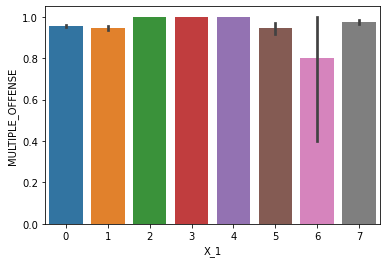

```python
## Below barplot describes which level of X_1 have more 1 of MULTIPLE_OFFENSE column.
sns.barplot(train['X_1'],train['MULTIPLE_OFFENSE']);
```

```python
## Below table describes which level of X_4 have more 1 of MULTIPLE_OFFENSE column.
train[["X_4", "MULTIPLE_OFFENSE"]].groupby(['X_4'], as_index=False).mean().sort_values(by='MULTIPLE_OFFENSE', ascending=False)
```

|  | X_4 | MULTIPLE_OFFENSE |
| --- | --- | --- |
| 5 | 5 | 1.000000 |
| 8 | 9 | 0.960294 |
| 7 | 7 | 0.960208 |
| 0 | 0 | 0.957421 |
| 3 | 3 | 0.956173 |
| 1 | 1 | 0.956005 |
| 2 | 2 | 0.955959 |
| 6 | 6 | 0.953611 |
| 4 | 4 | 0.947706 |
| 9 | 10 | 0.946860 |

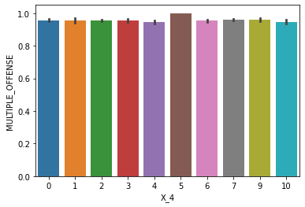

```python
## Below barplot  describes which level of X_4 have more 1 of MULTIPLE_OFFENSE column.
sns.barplot(train['X_4'],train['MULTIPLE_OFFENSE']);
```

```python
## Below table describes which level of X_5 have more 1 of MULTIPLE_OFFENSE column.
train[["X_5", "MULTIPLE_OFFENSE"]].groupby(['X_5'], as_index=False).mean().sort_values(by='MULTIPLE_OFFENSE', ascending=False)
```

|  | X_5 | MULTIPLE_OFFENSE |
| --- | --- | --- |
| 2 | 2 | 1.000000 |
| 0 | 0 | 0.958253 |
| 3 | 3 | 0.956163 |
| 4 | 5 | 0.954262 |
| 1 | 1 | 0.953505 |

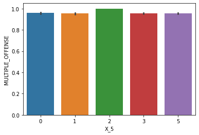

```python
## Below barplot  describes which level of X_5 have more 1 of MULTIPLE_OFFENSE column.
sns.barplot(train['X_5'],train['MULTIPLE_OFFENSE']);
```

```python
## Below table describes which level of X_6 have more 1 of MULTIPLE_OFFENSE column.
train[["X_6", "MULTIPLE_OFFENSE"]].groupby(['X_6'], as_index=False).mean().sort_values(by='MULTIPLE_OFFENSE', ascending=False)
```

|  | X_6 | MULTIPLE_OFFENSE |
| --- | --- | --- |
| 18 | 19 | 1.000000 |
| 8 | 9 | 0.969219 |
| 6 | 7 | 0.963692 |
| 1 | 2 | 0.962576 |
| 5 | 6 | 0.957779 |
| 4 | 5 | 0.957447 |
| 12 | 13 | 0.956835 |
| 7 | 8 | 0.953737 |
| 3 | 4 | 0.952997 |
| 0 | 1 | 0.950881 |
| 14 | 15 | 0.950820 |
| 2 | 3 | 0.949063 |
| 10 | 11 | 0.945000 |
| 13 | 14 | 0.944444 |
| 15 | 16 | 0.941935 |
| 17 | 18 | 0.938272 |
| 16 | 17 | 0.936364 |
| 11 | 12 | 0.923810 |
| 9 | 10 | 0.880000 |

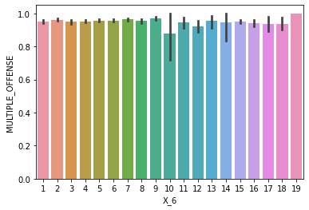

```python
## Below barplot  describes which level of X_6 have more 1 of MULTIPLE_OFFENSE column.
sns.barplot(train['X_6'],train['MULTIPLE_OFFENSE']);
```

```python
## Below table describes which level of X_7 have more 1 of MULTIPLE_OFFENSE column.
train[["X_7", "MULTIPLE_OFFENSE"]].groupby(['X_7'], as_index=False).mean().sort_values(by='MULTIPLE_OFFENSE', ascending=False)
```

|  | X_7 | MULTIPLE_OFFENSE |
| --- | --- | --- |
| 9 | 9 | 1.000000 |
| 8 | 8 | 0.969219 |
| 1 | 1 | 0.963692 |
| 7 | 7 | 0.962576 |
| 4 | 4 | 0.957779 |
| 6 | 6 | 0.957447 |
| 18 | 18 | 0.956835 |
| 3 | 3 | 0.953737 |
| 2 | 2 | 0.952997 |
| 0 | 0 | 0.950881 |
| 10 | 10 | 0.950820 |
| 5 | 5 | 0.949063 |
| 17 | 17 | 0.945000 |
| 14 | 14 | 0.944444 |
| 12 | 12 | 0.941935 |
| 13 | 13 | 0.938272 |
| 11 | 11 | 0.936364 |
| 16 | 16 | 0.923810 |
| 15 | 15 | 0.880000 |

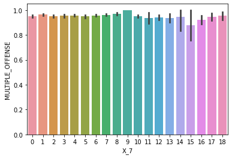

```python
## Below barplot  describes which level of X_7 have more 1 of MULTIPLE_OFFENSE column.
sns.barplot(train['X_7'],train['MULTIPLE_OFFENSE']);
```

```python
## Below table describes which month have more 1 of MULTIPLE_OFFENSE column.
train[["month", "MULTIPLE_OFFENSE"]].groupby(['month'], as_index=False).mean().sort_values(by='MULTIPLE_OFFENSE', ascending=False)
```

|  | month | MULTIPLE_OFFENSE |
| --- | --- | --- |
| 8 | 9 | 0.965939 |
| 1 | 2 | 0.959767 |
| 10 | 11 | 0.958446 |
| 6 | 7 | 0.957348 |
| 2 | 3 | 0.957286 |
| 7 | 8 | 0.956398 |
| 9 | 10 | 0.955098 |
| 5 | 6 | 0.954094 |
| 3 | 4 | 0.952696 |
| 11 | 12 | 0.949164 |
| 0 | 1 | 0.947671 |
| 4 | 5 | 0.946312 |

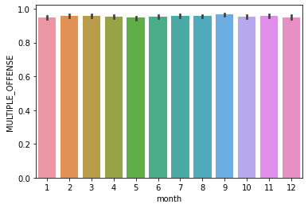

```python
## Below barplot  describes which month have more 1 of MULTIPLE_OFFENSE column.
sns.barplot(train['month'],train['MULTIPLE_OFFENSE']);
```

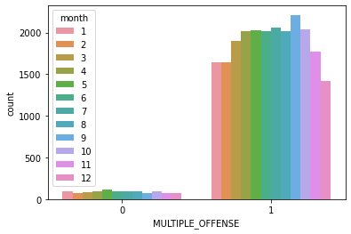

```python
## Below figure explains month counts with respect to MULTIPLE_OFFENSE.
sns.countplot(x = 'MULTIPLE_OFFENSE', hue = 'month', data = train)
```

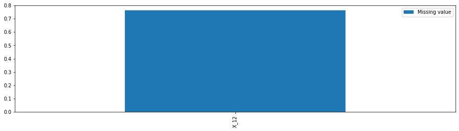

```python
## visualize missing train data.
missing_value = train.isnull().sum().sort_values(ascending=False) / len(train) * 100
missing_value = missing_value[missing_value != 0]
missing_value = pd.DataFrame({'Missing value' :missing_value,'Type':missing_value.index.map(lambda x:train[x].dtype)})
missing_value.plot(kind='bar',figsize=(16,4))
plt.show()
```

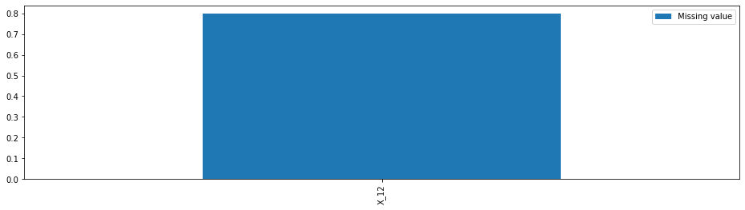

```python
## visualize missing test data.
missing_value = test.isnull().sum().sort_values(ascending=False) / len(test) * 100
missing_value = missing_value[missing_value != 0]
missing_value = pd.DataFrame({'Missing value' :missing_value,'Type':missing_value.index.map(lambda x:test[x].dtype)})
missing_value.plot(kind='bar',figsize=(16,4))
plt.show()
```

```python
## Get 0 & 1 counts for MULTIPLE_OFFENSE column of train data.
train['MULTIPLE_OFFENSE'].value_counts()
```

```
1    22788
0     1068
Name: MULTIPLE_OFFENSE, dtype: int64
```

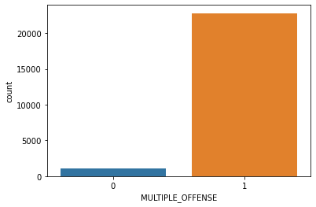

```python
## Visualize different levels count for MULTIPLE_OFFENSE column of train data.
sns.countplot(train['MULTIPLE_OFFENSE'])
```

```python
## Get different level counts for X_1 column of train data.
train['X_1'].value_counts()
```

```
0    19036
1     3497
7      876
5      270
3      136
4       26
2       10
6        5
Name: X_1, dtype: int64
```

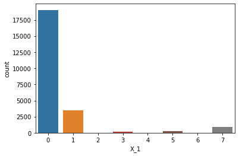

```python
## Visualize different levels count for X_1 column of train data.
sns.countplot(train['X_1'])
```

```python
## Get different level counts for X_1 column of test data.
test['X_1'].value_counts()
```

```
0    12778
1     2264
7      550
5      188
3       92
4       22
2        7
6        2
Name: X_1, dtype: int64
```

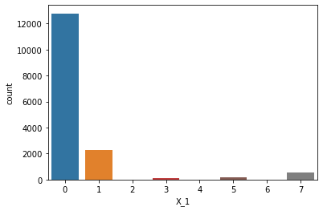

```python
## Visualize different levels count for X_1 column of test data.
sns.countplot(test['X_1'])
```

```python
## Get different level counts for X_4 column of train data.
train['X_4'].value_counts()
```

```
6     5497
2     4791
0     3335
7     2890
4     2027
3     1871
9     1360
10    1242
1      841
5        2
Name: X_4, dtype: int64
```

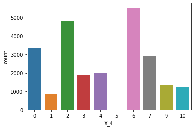

```python
## Visualize different levels count for X_4 column of train data.
sns.countplot(train['X_4'])
```

```python
## Get different level counts for X_4 column of test data.
test['X_4'].value_counts()
```

```
6     3581
2     3092
0     2253
7     1891
4     1342
3     1289
9      960
10     871
1      620
5        4
Name: X_4, dtype: int64
```

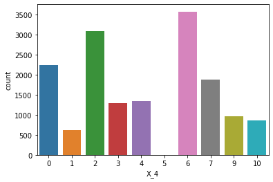

```python
## Visualize different levels count for X_4 column of test data.
sns.countplot(test['X_4'])
```

```python
## Get different level counts for X_5 column of train data.
train['X_5'].value_counts()
```

```
5    7368
1    6818
3    4973
0    4695
2       2
Name: X_5, dtype: int64
```

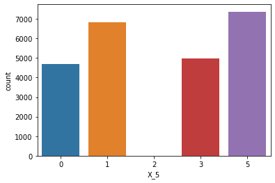

```python
## Visualize different levels count for X_5 column of train data.
sns.countplot(train['X_5'])
```

```python
## Get different level counts for X_5 column of test data.
test['X_5'].value_counts()
```

```
5    4870
1    4434
3    3382
0    3213
2       4
Name: X_5, dtype: int64
```

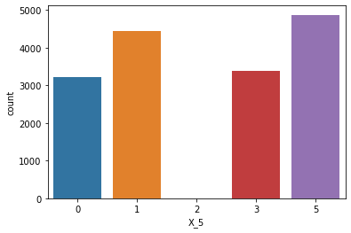

```python
## Visualize different levels count for X_5 column of test data.
sns.countplot(test['X_5'])
```

```python
## Get different level counts for X_6 column of train data.
train['X_6'].value_counts()
```

```
1     3461
5     2679
6     2629
4     2319
15    2318
2     2298
7     2286
3     1708
8     1405
9     1267
16     620
12     210
11     200
18     162
13     139
17     110
10      25
14      18
19       2
Name: X_6, dtype: int64
```

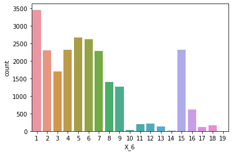

```python
## Visualize different levels count for X_6 column of train data.
sns.countplot(train['X_6'])
```

```python
## Get different level counts for X_6 column of test data.
test['X_6'].value_counts()
```

```
1     2333
5     1797
6     1761
2     1565
4     1550
15    1504
7     1442
3     1201
8      951
9      831
16     406
12     129
11     127
18     102
13     101
17      73
10      14
14      13
19       3
Name: X_6, dtype: int64
```

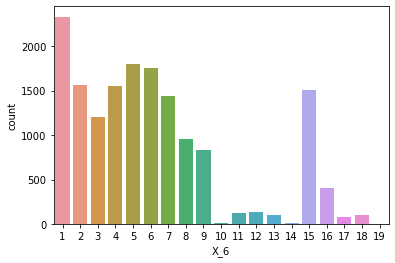

```python
## Visualize different levels count for X_6 column of test data.
sns.countplot(test['X_6'])
```

```python
## Get different level counts for X_7 column of train data.
train['X_7'].value_counts()
```

```
0     3461
6     2679
4     2629
2     2319
10    2318
7     2298
1     2286
5     1708
3     1405
8     1267
12     620
16     210
17     200
13     162
18     139
11     110
15      25
14      18
9        2
Name: X_7, dtype: int64
```

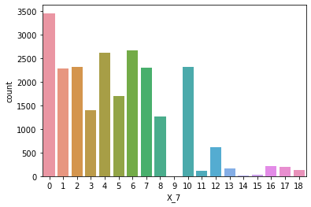

```python
## Visualize different levels count for X_7 column of train data.
sns.countplot(train['X_7'])
```

```python
## Get different level counts for X_7 column of test data.
test['X_7'].value_counts()
```

```
0     2333
6     1797
4     1761
7     1565
2     1550
10    1504
1     1442
5     1201
3      951
8      831
12     406
16     129
17     127
13     102
18     101
11      73
15      14
14      13
9        3
Name: X_7, dtype: int64
```

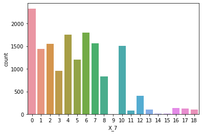

```python
## Visualize different levels count for X_7 column of test data.
sns.countplot(test['X_7'])
```

```python
## Get different level counts for X_9 column of train data.
train['X_9'].value_counts()
```

```
5    10559
6     9508
2     3040
3      452
1      175
0      118
4        4
Name: X_9, dtype: int64
```

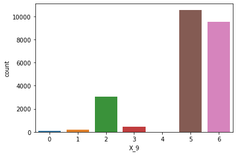

```python
## Visualize different levels count for X_9 column of train data.
sns.countplot(train['X_9'])
```

```python
## Get different level counts for month column of train data.
train['month'].value_counts()
```

```
9     2290
7     2157
5     2142
10    2138
4     2114
6     2113
8     2110
3     1990
11    1853
1     1739
2     1715
12    1495
Name: month, dtype: int64
```

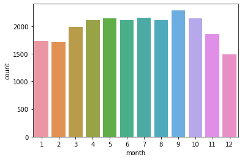

```python
## Visualize different levels count for month column of train data.
sns.countplot(train['month'])
```

```python
## check for corrlation between numeric columns of train data.
train[train.select_dtypes(['int64','float64']).columns].corr()
```

|  | X_1 | X_2 | X_3 | X_4 | X_5 | X_6 | X_7 | X_8 | X_9 | X_10 | X_11 | X_12 | X_13 | X_14 | X_15 | MULTIPLE_OFFENSE | year | month | day |
| --- | --- | --- | --- | --- | --- | --- | --- | --- | --- | --- | --- | --- | --- | --- | --- | --- | --- | --- | --- |
| X_1 | 1.000000 | 0.021999 | 0.022603 | 0.002137 | -0.034220 | 0.409876 | 0.421454 | -0.061897 | 0.017984 | 0.004155 | -0.003078 | -0.034835 | 0.111611 | -0.012708 | -0.012132 | 0.014034 | 0.007982 | 0.014748 | -0.010353 |
| X_2 | 0.021999 | 1.000000 | 0.996985 | -0.104321 | -0.349190 | 0.119718 | 0.058806 | -0.038174 | -0.017749 | -0.016710 | 0.038003 | -0.067720 | 0.046668 | 0.015194 | 0.013822 | -0.027293 | -0.006115 | 0.019820 | 0.007042 |
| X_3 | 0.022603 | 0.996985 | 1.000000 | -0.075344 | -0.347519 | 0.124662 | 0.072954 | -0.033035 | -0.019853 | -0.014485 | 0.036946 | -0.064872 | 0.043201 | 0.013522 | 0.006851 | -0.027218 | -0.000382 | 0.020165 | 0.008486 |
| X_4 | 0.002137 | -0.104321 | -0.075344 | 1.000000 | 0.439616 | 0.028929 | 0.094076 | 0.075197 | -0.008453 | 0.038077 | -0.037614 | 0.059135 | -0.051861 | -0.030024 | -0.033198 | -0.002921 | -0.013115 | -0.014066 | 0.003684 |
| X_5 | -0.034220 | -0.349190 | -0.347519 | 0.439616 | 1.000000 | -0.062784 | 0.010161 | 0.046926 | 0.046428 | 0.046212 | -0.043111 | 0.082068 | -0.071233 | -0.003413 | -0.036383 | -0.003450 | 0.021806 | -0.014293 | -0.010091 |
| X_6 | 0.409876 | 0.119718 | 0.124662 | 0.028929 | -0.062784 | 1.000000 | 0.695243 | -0.063541 | 0.079192 | 0.021186 | -0.002990 | -0.031258 | 0.047845 | -0.013155 | -0.006621 | -0.007903 | 0.013365 | 0.007623 | -0.000548 |
| X_7 | 0.421454 | 0.058806 | 0.072954 | 0.094076 | 0.010161 | 0.695243 | 1.000000 | -0.011824 | 0.011519 | 0.023205 | 0.002970 | -0.000409 | 0.012204 | 0.003738 | -0.003277 | -0.008036 | 0.046466 | 0.010249 | 0.001720 |
| X_8 | -0.061897 | -0.038174 | -0.033035 | 0.075197 | 0.046926 | -0.063541 | -0.011824 | 1.000000 | -0.090184 | 0.222004 | 0.009424 | 0.273107 | -0.048140 | 0.003987 | 0.017636 | -0.033397 | -0.044003 | -0.014518 | 0.005398 |
| X_9 | 0.017984 | -0.017749 | -0.019853 | -0.008453 | 0.046428 | 0.079192 | 0.011519 | -0.090184 | 1.000000 | 0.013388 | -0.006152 | 0.005150 | 0.023537 | -0.297295 | 0.006475 | -0.000748 | -0.024982 | 0.002830 | 0.002622 |
| X_10 | 0.004155 | -0.016710 | -0.014485 | 0.038077 | 0.046212 | 0.021186 | 0.023205 | 0.222004 | 0.013388 | 1.000000 | -0.045596 | 0.877743 | 0.002332 | -0.016519 | -0.003336 | -0.242596 | -0.026443 | -0.001042 | 0.000753 |
| X_11 | -0.003078 | 0.038003 | 0.036946 | -0.037614 | -0.043111 | -0.002990 | 0.002970 | 0.009424 | -0.006152 | -0.045596 | 1.000000 | 0.027363 | 0.017055 | -0.009531 | 0.017267 | 0.105088 | 0.022499 | 0.002769 | -0.013971 |
| X_12 | -0.034835 | -0.067720 | -0.064872 | 0.059135 | 0.082068 | -0.031258 | -0.000409 | 0.273107 | 0.005150 | 0.877743 | 0.027363 | 1.000000 | 0.030012 | -0.042033 | 0.044005 | -0.113061 | -0.015605 | -0.002993 | 0.002759 |
| X_13 | 0.111611 | 0.046668 | 0.043201 | -0.051861 | -0.071233 | 0.047845 | 0.012204 | -0.048140 | 0.023537 | 0.002332 | 0.017055 | 0.030012 | 1.000000 | -0.063373 | 0.004041 | 0.006512 | -0.021096 | -0.009421 | 0.005064 |
| X_14 | -0.012708 | 0.015194 | 0.013522 | -0.030024 | -0.003413 | -0.013155 | 0.003738 | 0.003987 | -0.297295 | -0.016519 | -0.009531 | -0.042033 | -0.063373 | 1.000000 | 0.011804 | -0.015267 | 0.024830 | 0.008394 | -0.003909 |
| X_15 | -0.012132 | 0.013822 | 0.006851 | -0.033198 | -0.036383 | -0.006621 | -0.003277 | 0.017636 | 0.006475 | -0.003336 | 0.017267 | 0.044005 | 0.004041 | 0.011804 | 1.000000 | 0.044916 | -0.069230 | 0.002090 | -0.000024 |
| MULTIPLE_OFFENSE | 0.014034 | -0.027293 | -0.027218 | -0.002921 | -0.003450 | -0.007903 | -0.008036 | -0.033397 | -0.000748 | -0.242596 | 0.105088 | -0.113061 | 0.006512 | -0.015267 | 0.044916 | 1.000000 | -0.002755 | 0.006736 | 0.004736 |
| year | 0.007982 | -0.006115 | -0.000382 | -0.013115 | 0.021806 | 0.013365 | 0.046466 | -0.044003 | -0.024982 | -0.026443 | 0.022499 | -0.015605 | -0.021096 | 0.024830 | -0.069230 | -0.002755 | 1.000000 | 0.016536 | -0.007497 |
| month | 0.014748 | 0.019820 | 0.020165 | -0.014066 | -0.014293 | 0.007623 | 0.010249 | -0.014518 | 0.002830 | -0.001042 | 0.002769 | -0.002993 | -0.009421 | 0.008394 | 0.002090 | 0.006736 | 0.016536 | 1.000000 | -0.006513 |
| day | -0.010353 | 0.007042 | 0.008486 | 0.003684 | -0.010091 | -0.000548 | 0.001720 | 0.005398 | 0.002622 | 0.000753 | -0.013971 | 0.002759 | 0.005064 | -0.003909 | -0.000024 | 0.004736 | -0.007497 | -0.006513 | 1.000000 |

```python
## check for corrlation between numeric columns of test data.
test[test.select_dtypes(['int64','float64']).columns].corr()
```

|  | X_1 | X_2 | X_3 | X_4 | X_5 | X_6 | X_7 | X_8 | X_9 | X_10 | X_11 | X_12 | X_13 | X_14 | X_15 | year | month | day |
| --- | --- | --- | --- | --- | --- | --- | --- | --- | --- | --- | --- | --- | --- | --- | --- | --- | --- | --- |
| X_1 | 1.000000 | 0.030496 | 0.030976 | -0.005326 | -0.039203 | 0.414001 | 0.425840 | -0.067898 | 0.014131 | -0.014896 | 0.004205 | -0.064810 | 0.101348 | -0.001934 | -0.021650 | 0.008841 | 0.006081 | -0.000176 |
| X_2 | 0.030496 | 1.000000 | 0.996932 | -0.104985 | -0.364487 | 0.123955 | 0.069277 | -0.052522 | -0.027721 | -0.025326 | 0.054676 | -0.083900 | 0.044121 | 0.019978 | 0.007575 | -0.003137 | 0.020983 | 0.006320 |
| X_3 | 0.030976 | 0.996932 | 1.000000 | -0.076411 | -0.364235 | 0.129570 | 0.084448 | -0.049484 | -0.028606 | -0.022261 | 0.053582 | -0.080060 | 0.042015 | 0.018218 | 0.001069 | 0.002590 | 0.021498 | 0.006617 |
| X_4 | -0.005326 | -0.104985 | -0.076411 | 1.000000 | 0.422509 | 0.019798 | 0.097095 | 0.058194 | -0.035503 | 0.042284 | -0.051579 | 0.068968 | -0.048783 | -0.022423 | -0.037745 | -0.009295 | -0.010179 | -0.004660 |
| X_5 | -0.039203 | -0.364487 | -0.364235 | 0.422509 | 1.000000 | -0.069090 | 0.004112 | 0.062754 | 0.029654 | 0.062653 | -0.060479 | 0.107222 | -0.074455 | -0.013293 | -0.051209 | 0.022549 | -0.016196 | -0.010678 |
| X_6 | 0.414001 | 0.123955 | 0.129570 | 0.019798 | -0.069090 | 1.000000 | 0.693056 | -0.065980 | 0.086701 | 0.018853 | -0.006849 | -0.057221 | 0.049206 | -0.011291 | -0.016444 | 0.010781 | 0.032021 | -0.009844 |
| X_7 | 0.425840 | 0.069277 | 0.084448 | 0.097095 | 0.004112 | 0.693056 | 1.000000 | -0.018485 | 0.017643 | 0.031901 | -0.008877 | -0.004669 | 0.005569 | 0.006395 | -0.013684 | 0.033307 | 0.020001 | 0.003184 |
| X_8 | -0.067898 | -0.052522 | -0.049484 | 0.058194 | 0.062754 | -0.065980 | -0.018485 | 1.000000 | -0.108924 | 0.123427 | -0.025773 | 0.204437 | -0.055066 | 0.002362 | 0.020029 | -0.047080 | -0.008184 | -0.011899 |
| X_9 | 0.014131 | -0.027721 | -0.028606 | -0.035503 | 0.029654 | 0.086701 | 0.017643 | -0.108924 | 1.000000 | -0.006901 | -0.005082 | -0.018356 | 0.030556 | -0.304968 | -0.003338 | -0.022973 | 0.004765 | 0.007165 |
| X_10 | -0.014896 | -0.025326 | -0.022261 | 0.042284 | 0.062653 | 0.018853 | 0.031901 | 0.123427 | -0.006901 | 1.000000 | -0.051959 | 0.749450 | 0.000625 | -0.004596 | -0.011161 | -0.015268 | 0.004992 | 0.002220 |
| X_11 | 0.004205 | 0.054676 | 0.053582 | -0.051579 | -0.060479 | -0.006849 | -0.008877 | -0.025773 | -0.005082 | -0.051959 | 1.000000 | 0.041741 | 0.042452 | 0.006351 | 0.023575 | 0.024415 | -0.016038 | -0.008448 |
| X_12 | -0.064810 | -0.083900 | -0.080060 | 0.068968 | 0.107222 | -0.057221 | -0.004669 | 0.204437 | -0.018356 | 0.749450 | 0.041741 | 1.000000 | 0.049161 | -0.041544 | 0.054826 | 0.006344 | -0.010916 | -0.003951 |
| X_13 | 0.101348 | 0.044121 | 0.042015 | -0.048783 | -0.074455 | 0.049206 | 0.005569 | -0.055066 | 0.030556 | 0.000625 | 0.042452 | 0.049161 | 1.000000 | -0.067128 | 0.019368 | -0.004698 | -0.015724 | -0.011471 |
| X_14 | -0.001934 | 0.019978 | 0.018218 | -0.022423 | -0.013293 | -0.011291 | 0.006395 | 0.002362 | -0.304968 | -0.004596 | 0.006351 | -0.041544 | -0.067128 | 1.000000 | 0.000818 | 0.033875 | 0.001147 | 0.000131 |
| X_15 | -0.021650 | 0.007575 | 0.001069 | -0.037745 | -0.051209 | -0.016444 | -0.013684 | 0.020029 | -0.003338 | -0.011161 | 0.023575 | 0.054826 | 0.019368 | 0.000818 | 1.000000 | -0.074072 | -0.002260 | -0.014204 |
| year | 0.008841 | -0.003137 | 0.002590 | -0.009295 | 0.022549 | 0.010781 | 0.033307 | -0.047080 | -0.022973 | -0.015268 | 0.024415 | 0.006344 | -0.004698 | 0.033875 | -0.074072 | 1.000000 | 0.008334 | 0.002014 |
| month | 0.006081 | 0.020983 | 0.021498 | -0.010179 | -0.016196 | 0.032021 | 0.020001 | -0.008184 | 0.004765 | 0.004992 | -0.016038 | -0.010916 | -0.015724 | 0.001147 | -0.002260 | 0.008334 | 1.000000 | -0.017804 |
| day | -0.000176 | 0.006320 | 0.006617 | -0.004660 | -0.010678 | -0.009844 | 0.003184 | -0.011899 | 0.007165 | 0.002220 | -0.008448 | -0.003951 | -0.011471 | 0.000131 | -0.014204 | 0.002014 | -0.017804 | 1.000000 |

```python
## By looking into correlation table we can say X_2 & X_3 are in mutlicollinearity.So we can drop either X_2 or X_3.
train.drop('X_3',axis=1,inplace=True)
test.drop('X_3',axis=1,inplace=True)
```

```python
## fill NA values with zero for train and test data.
train['X_12'].fillna(0,inplace=True)
test['X_12'].fillna(0,inplace=True)
```

```python
## Check train data null values after doing imputation.
train.isna().sum()
```

```
X_1                 0
X_2                 0
X_4                 0
X_5                 0
X_6                 0
X_7                 0
X_8                 0
X_9                 0
X_10                0
X_11                0
X_12                0
X_13                0
X_14                0
X_15                0
MULTIPLE_OFFENSE    0
year                0
month               0
day                 0
dtype: int64
```

```python
## Check test data null values after doing imputation.
test.isna().sum()
```

```
X_1      0
X_2      0
X_4      0
X_5      0
X_6      0
X_7      0
X_8      0
X_9      0
X_10     0
X_11     0
X_12     0
X_13     0
X_14     0
X_15     0
year     0
month    0
day      0
dtype: int64
```

```python
## Convert data types.
train['X_12']=train['X_12'].astype('int64')
test['X_12']=test['X_12'].astype('int64')
```

```python
## Store train data features into train_data.
train_data = train.drop('MULTIPLE_OFFENSE', axis=1)
```

```python
## Store train data MULTIPLE_OFFENSE column into y.
y = train['MULTIPLE_OFFENSE']
```

```python
## Split the train data into  train and validation.
X_train,X_test,y_train,y_test = train_test_split(train_data,y,test_size=0.2,random_state =1234)
```

```python
## Instantiate label encoder.
le_year = LabelEncoder()
le_month = LabelEncoder()
le_day = LabelEncoder()
le_multiple_offense = LabelEncoder()

## We don't have complete description about columns,based on column levels i have asssumed those are categorical varibles.
## Initially i build the model by treating all columns as interges but accuracy is less compred to below one.

le_X_1 = LabelEncoder()
le_X_4 = LabelEncoder()
le_X_5 = LabelEncoder()
le_X_6 = LabelEncoder()
le_X_7 = LabelEncoder()
le_X_9 = LabelEncoder()
```

```python
## Do labe encoding for trian data.
X_train['year'] = le_year.fit_transform(X_train['year'])
X_train['month'] = le_month.fit_transform(X_train['month'])
X_train['day'] = le_day.fit_transform(X_train['day'])

X_train['X_1'] = le_X_1.fit_transform(X_train['X_1'])
X_train['X_4'] = le_X_4.fit_transform(X_train['X_4'])
X_train['X_5'] = le_X_5.fit_transform(X_train['X_5'])
X_train['X_6'] = le_X_6.fit_transform(X_train['X_6'])
X_train['X_7'] = le_X_7.fit_transform(X_train['X_7'])
X_train['X_9'] = le_X_9.fit_transform(X_train['X_9'])
```

[output not shown]

```python
## Do labe encoding for validation data.
X_test['year'] = le_year.transform(X_test['year'])
X_test['month'] = le_month.transform(X_test['month'])
X_test['day'] = le_day.transform(X_test['day'])

X_test['X_1'] = le_X_1.transform(X_test['X_1'])
X_test['X_4'] = le_X_4.transform(X_test['X_4'])
X_test['X_5'] = le_X_5.transform(X_test['X_5'])
X_test['X_6'] = le_X_6.transform(X_test['X_6'])
X_test['X_7'] = le_X_7.transform(X_test['X_7'])
X_test['X_9'] = le_X_9.transform(X_test['X_9'])
```

[output not shown]

```python
## Do labe encoding for test data.
test['year'] = le_year.transform(test['year'])
test['month'] = le_month.transform(test['month'])
test['day'] = le_day.transform(test['day'])

test['X_1'] = le_X_1.transform(test['X_1'])
test['X_4'] = le_X_4.transform(test['X_4'])
test['X_5'] = le_X_5.transform(test['X_5'])
test['X_6'] = le_X_6.transform(test['X_6'])
test['X_7'] = le_X_7.transform(test['X_7'])
test['X_9'] = le_X_9.transform(test['X_9'])
```

```python
## Do label encoding for target for train data.
y_train = le_multiple_offense.fit_transform(y_train)
```

```python
## Do label encoding for target for validation data.
y_test = le_multiple_offense.transform(y_test)
```